# Model Diagnostic Comparisons

## Overview

Diagnostics from initial models demonstrated issues with kurtosis, nonlinearity, and heteroskedasticity. The goal of this comparison is to explore whether other modeling options improve these issues. The focal species is blue rockfish (Sebastes mystinus), a species found statewide that is generally associated with hard bottom and hard bottom biotic (kelp) habitat. The top model for this species from the original approach was:

Log-Transformed Biomass ~ Hard 0-30 at 500m * Site Type + Site Type * MPA Age

- Generalized linear mixed effects models (current approach)
  - Does log-transforming biomass make a difference in model fit?
  - Does adding a 3-way interaction with MPA age make a difference in model fit?
- Gamma-distributed generalized linear mixed effects models
  - Does adding a gamma distribution make a difference in model fit?
- Generalized additive models with smoothing term for MPA age
  - Would a GAM better capture the nonlinear effects?
  - What specification is most appropriate?

## Build

### General

- Gamma GLMs require that the response variable is strictly positive, so will add a small constant that is 10x smaller than the minimum observed biomass value. (Tried without this and verified that this is necessary).
- Center and scale the predictor variables to accommodate differences in scales (habitat measured in square meters, age measured in years).

```r
# Define constant 10x smaller than minimum nonzero biomass
const <- min(data_kelp$kg_per_m2[data_kelp$kg_per_m2 > 0])/10

data_sp <- data_kelp  %>%
  # Add small constant for gamma distribution
  mutate(kg_per_m2_c = kg_per_m2 + const) %>%
  # Center and scale all numeric vars except the one with added constant
  mutate(age_at_survey = as.numeric(scale(age_at_survey)),
         #kg_per_m2 = as.numeric(scale(kg_per_m2)),
         #log_kg_per_m2 = as.numeric(scale(log_kg_per_m2)),
         hard_bottom_0_30m_500 =  as.numeric(scale(hard_bottom_0_30m_500)))
```

## Functions for Partial Residuals

Partial residuals represent the response variable adjusted for all other terms in the model, leaving behind the residual signal and the contribution of the term of interest (TOI).

- Partial Residuals = Response - Predictions (Excluding TOI) + Effect of TOI

- ```
    = (Full Residuals) + Effect of TOI
  ```

The following function will:

- Extract the residuals, model matrix, and fixed-effects coefficients
- Multiply the matrix by the corresponding coefficients to get the effect of each TOI
- Add the residuals to each TOI effect
- Plot those partial residuals for MPA Age and Hard Bottom 0-30

```r
# Select term columns to join with residuals df
data_terms <- data_sp %>%
  dplyr::select(obs_id, age_at_survey, site_type, hard_bottom_0_30m_500)

# Create function to extract the residuals and plot with smooths
plot_partial_residuals <- function(model){
  # Extract residuals, model matrix, and fixed-effects coefficients
  resid <- residuals(model)
  model_mat <- model.matrix(model)
  fixed_coefs <- fixef(model)

  # Ensure they are aligned
  if (identical(colnames(model_mat), names(fixed_coefs))){

    # Multiply each column of the model matrix by its corresponding coefficient
    # to get the effect of each separate predictor term
    part_resid <- sweep(model_mat, 2, fixed_coefs, `*`) %>%
      as.data.frame() %>%
      # Add the residuals to each predictor effect
      mutate(across(everything(), ~.x + resid)) %>%
      mutate(obs_id = row_number(data_sp)) %>%
      # Lengthen to make one facet for each term
      pivot_longer(cols = -obs_id,
                   names_to = "term", values_to = "partial_residual") %>%
      full_join(., data_terms, by = "obs_id") %>%
      filter(term != "(Intercept)")

    # Plot the partial residuals for each age term
    age <- ggplot(part_resid %>% filter(str_detect(term, "age_at_survey"))) +
      geom_smooth(aes(x = age_at_survey, y = partial_residual, color = site_type)) +
      labs(title = paste(attr(model, "name")),
           x = "Age at survey",
           y = "Partial residual", color = NULL) +
      scale_color_manual(values = c("#7e67f8", "#e5188b")) +
      my_theme +
      facet_wrap(~term)

    # Plot the partial residuals for each habitat term
    habitat <- ggplot(part_resid%>% filter(str_detect(term, "hard"))) +
      geom_smooth(aes(x = hard_bottom_0_30m_500,
                      y = partial_residual, color = site_type),
                  show.legend = F) +
      labs(x = "Hard bottom 0-30m 500",
           y = "Partial residual", color = NULL) +
      scale_color_manual(values = c("#7e67f8", "#e5188b")) +
      my_theme +
      facet_wrap(~term)

    return(age / habitat)
  }
  else {
    print("Misaligned.")
  }
}
```

# GLMMs

1. GLMM, no transformation, 2-way interactions

```r
glm1 <- lmer(kg_per_m2 ~ hard_bottom_0_30m_500 * site_type + site_type * age_at_survey +
               (1|bioregion) + (1|affiliated_mpa) + (1|year), data = data_sp, REML = FALSE)

attr(glm1, "name") <- "GLMM: B ~ H*ST + ST*A"
```

2. GLMM, log-transformed biomass, 2-way interactions

```r
glm2 <- lmer(log_kg_per_m2 ~ hard_bottom_0_30m_500 * site_type + site_type * age_at_survey +
               (1|bioregion) + (1|affiliated_mpa) + (1|year), data = data_sp, REML = FALSE)

attr(glm2, "name") <- "GLMM: logB ~ H*ST + ST*A"
```

3. GLMM, no transformation, 3-way interaction

```r
glm3 <- lmer(kg_per_m2 ~ hard_bottom_0_30m_500 * site_type * age_at_survey +
               (1|bioregion) + (1|affiliated_mpa) + (1|year), data = data_sp, REML = FALSE)

attr(glm3, "name") <- "GLMM: B ~ H*ST*A"
```

4. GLMM, log-transformed biomass, 3-way interaction

```r
glm4 <- lmer(log_kg_per_m2 ~ hard_bottom_0_30m_500 * site_type * age_at_survey +
               (1|bioregion) + (1|affiliated_mpa) + (1|year), data = data_sp, REML = FALSE)

attr(glm4, "name") <- "GLMM: logB ~ H*ST*A"
```

## GLMM Comparison & Diagnostics

Click the tabs below to explore the model comparison and diagnostic plots.

**Comparison**

```r
model_fit <- bind_rows(model_performance(glm1, estimator = "ML") %>% mutate(Model = attr(glm1, "name")),
                       model_performance(glm2, estimator = "ML") %>% mutate(Model = attr(glm2, "name")),
                       model_performance(glm3, estimator = "ML") %>% mutate(Model = attr(glm3, "name")),
                       model_performance(glm4, estimator = "ML") %>% mutate(Model = attr(glm4, "name"))) %>%
  mutate(deltaAIC = AIC - min(AIC, na.rm = T)) %>%
  dplyr::select(Model, everything()) %>%
  arrange(AIC)

print(model_fit)
```

```
# Indices of model performance

Model                    |       AIC |      AICc |       BIC | R2 (cond.) | R2 (marg.) |   ICC |  RMSE | Sigma | deltaAIC
-------------------------------------------------------------------------------------------------------------------------
GLMM: logB ~ H*ST*A      | -8925.888 | -8925.708 | -8860.293 |      0.436 |      0.029 | 0.419 | 0.018 | 0.018 |    0.000
GLMM: logB ~ H*ST + ST*A | -8915.346 | -8915.220 | -8860.684 |      0.428 |      0.024 | 0.414 | 0.018 | 0.018 |   10.542
GLMM: B ~ H*ST*A         | -8662.227 | -8662.047 | -8596.632 |      0.423 |      0.029 | 0.405 | 0.020 | 0.020 |  263.661
GLMM: B ~ H*ST + ST*A    | -8652.022 | -8651.895 | -8597.360 |      0.415 |      0.024 | 0.401 | 0.020 | 0.020 |  273.866
```

**Residuals vs Fitted**

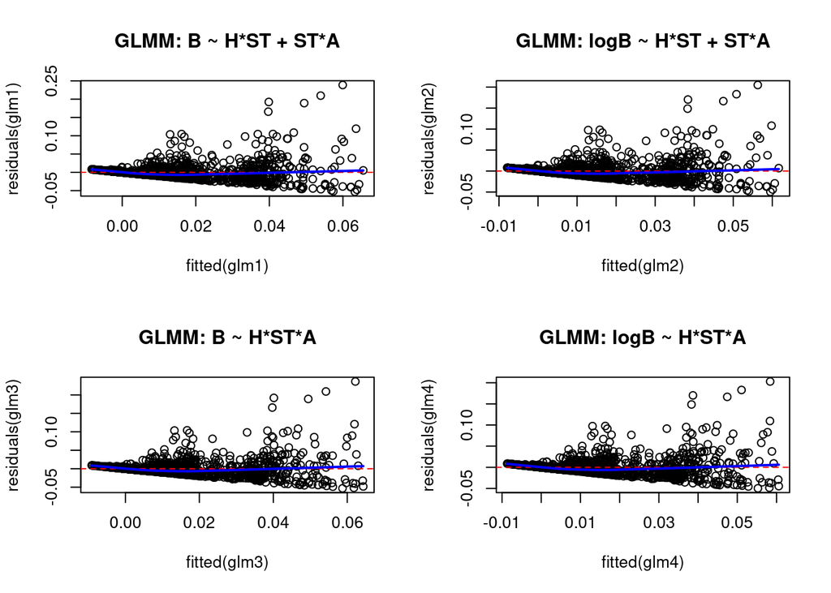

```r
par(mfrow = c(2, 2))

plot(residuals(glm1) ~ fitted(glm1), main = attr(glm1, "name"))
abline(h = 0, col = "red", lty = 2)
lines(lowess(fitted(glm1), residuals(glm1)), col = "blue", lwd = 2)

plot(residuals(glm2) ~ fitted(glm2), main = attr(glm2, "name"))
abline(h = 0, col = "red", lty = 2)
lines(lowess(fitted(glm2), residuals(glm2)), col = "blue", lwd = 2)


plot(residuals(glm3) ~ fitted(glm3), main = attr(glm3, "name"))
abline(h = 0, col = "red", lty = 2)
lines(lowess(fitted(glm3), residuals(glm3)), col = "blue", lwd = 2)


plot(residuals(glm4) ~ fitted(glm4), main = attr(glm4, "name"))
abline(h = 0, col = "red", lty = 2)
lines(lowess(fitted(glm4), residuals(glm4)), col = "blue", lwd = 2)
```

**Normal QQ**

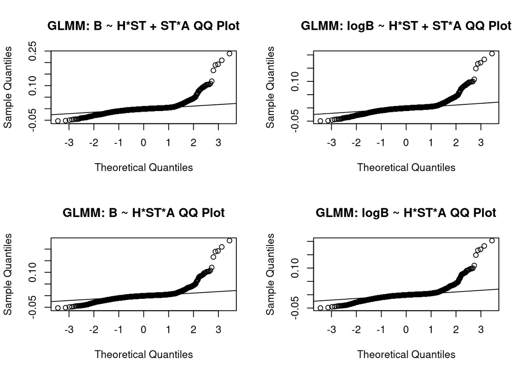

```r
par(mfrow = c(2, 2))

qqnorm(residuals(glm1), main = paste(attr(glm1, "name"), "QQ Plot")); qqline(residuals(glm1))
qqnorm(residuals(glm2), main = paste(attr(glm2, "name"), "QQ Plot")); qqline(residuals(glm2))
qqnorm(residuals(glm3), main = paste(attr(glm3, "name"), "QQ Plot")); qqline(residuals(glm3))
qqnorm(residuals(glm4), main = paste(attr(glm4, "name"), "QQ Plot")); qqline(residuals(glm4))
```

## GLMM Partial Residuals

**GLMM: B ~ H * ST + ST * A**

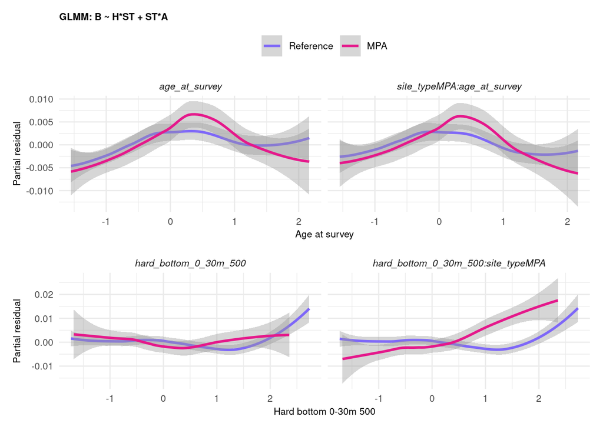

**GLMM: logB ~ H * ST + ST * A**

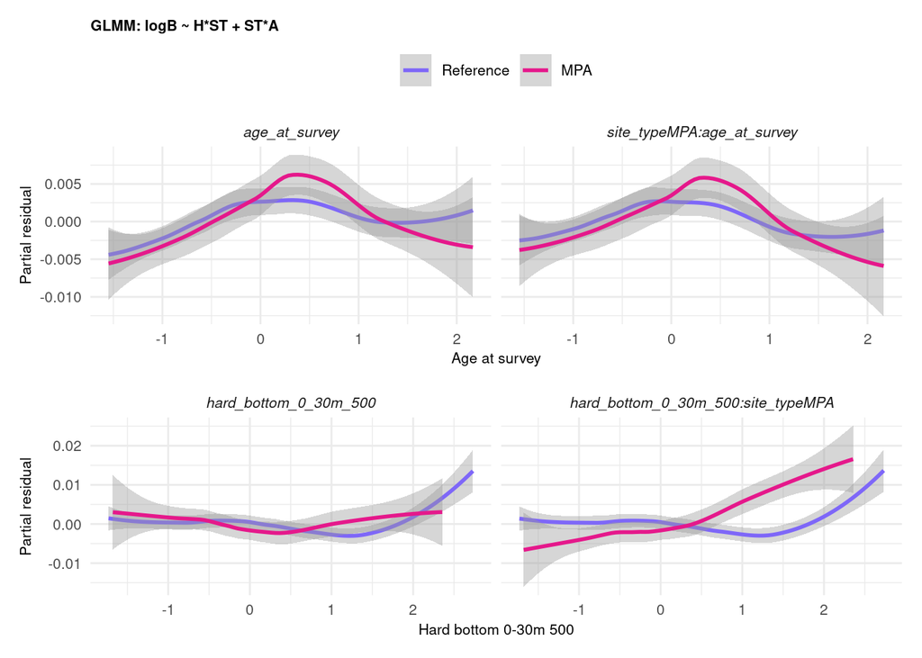

**GLMM: B ~ H * ST * A**

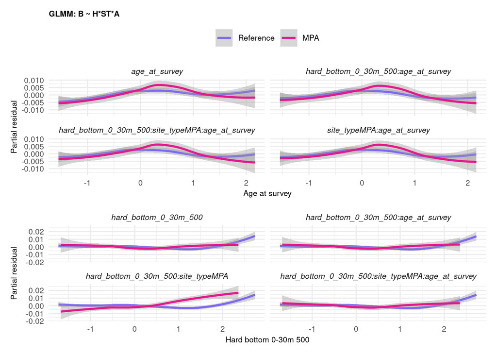

**GLMM: logB ~ H * ST * A**

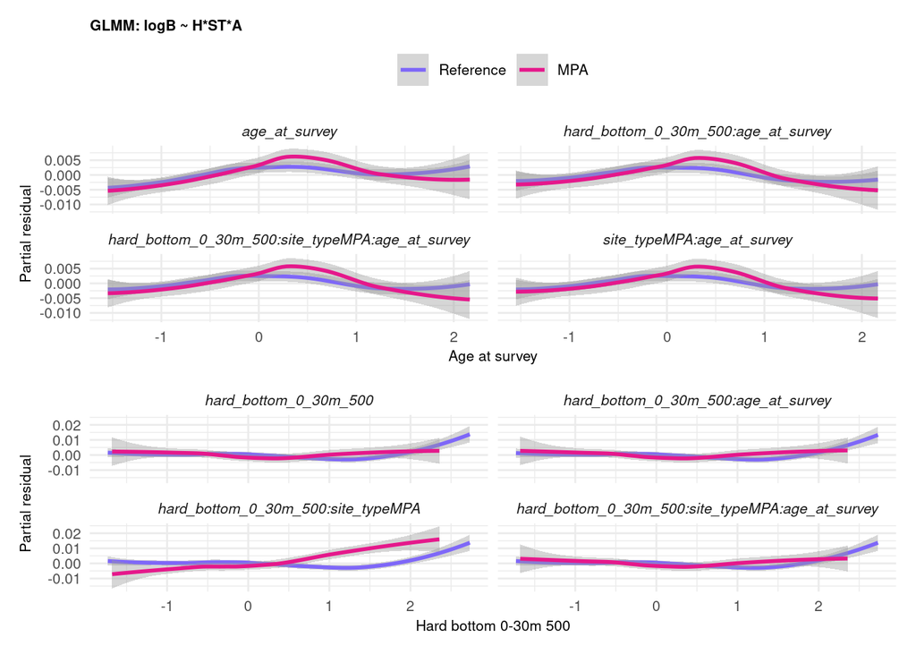

## GLMM Summary

- The diagnostic plots don’t show drastic differences among the four GLMMs
- The three-way interactions have the lowest AIC and highest R2 values
- Partial residuals show consistent nonlinear relationship with age (?) and potential nonlinear interaction between hard bottom and site type

# Gamma GLMs

1. Fit Gamma GLM + 2way

```r
gglm1 <- glmer(kg_per_m2_c ~ hard_bottom_0_30m_500 * site_type + site_type * age_at_survey + (1|bioregion) + (1|affiliated_mpa) + (1|year),
            family = Gamma(link = "log"), data = data_sp)

attr(gglm1, "name") <- "Gamma: B ~ H*ST + ST*A"
```

2. Fit Gamma GLM + 3way

```r
gglm2 <- glmer(kg_per_m2_c  ~ hard_bottom_0_30m_500 * site_type * age_at_survey + (1|bioregion) + (1|affiliated_mpa) + (1|year),
            family = Gamma(link = "log"), data_sp)

attr(gglm2, "name") <- "Gamma: B ~ H*ST*A"
```

## Gamma GLM Comparison

Click the tabs below to explore the model comparison and diagnostic plots.

**Comparison**

```r
model_fit <- bind_rows(model_performance(gglm1) %>% mutate(Model = attr(gglm1, "name")),
                       model_performance(gglm2) %>% mutate(Model = attr(gglm2, "name"))) %>%
  mutate(deltaAIC = AIC - min(AIC, na.rm = T)) %>%
  dplyr::select(Model, everything()) %>%
  arrange(AIC)

print(model_fit)
```

```
# Indices of model performance

Model                  |        AIC |       AICc |        BIC | R2 (cond.) | R2 (marg.) |   ICC |  RMSE | Sigma | deltaAIC
--------------------------------------------------------------------------------------------------------------------------
Gamma: B ~ H*ST*A      | -23532.635 | -23532.455 | -23467.040 |      0.987 |      0.001 | 0.987 | 0.097 | 2.358 |    0.000
Gamma: B ~ H*ST + ST*A | -23479.315 | -23479.188 | -23424.652 |      0.987 |  4.397e-04 | 0.987 | 0.107 | 2.405 |   53.320
```

**QQ Deviance**

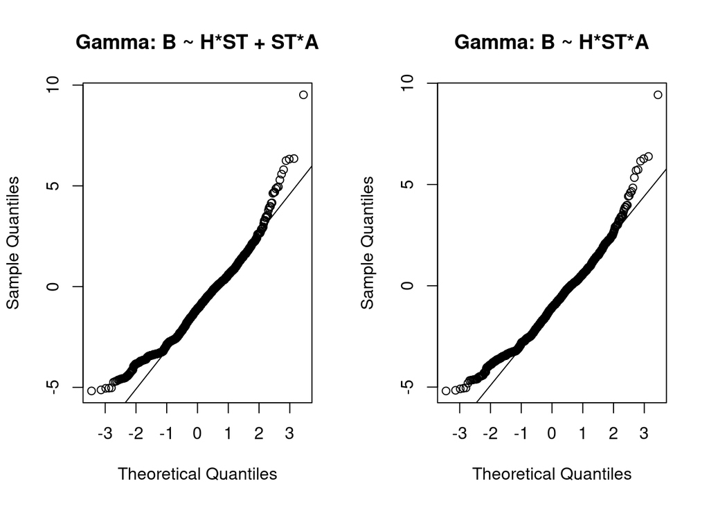

```r
par(mfrow = c(1, 2))

qqnorm(residuals(gglm1, type = "deviance"), main = paste(attr(gglm1, "name")))
qqline(residuals(gglm1, type = "deviance"))

qqnorm(residuals(gglm2, type = "deviance"), main = paste(attr(gglm2, "name")))
qqline(residuals(gglm2, type = "deviance"))
```

## Gamma GLM Partial Residuals

**Gamma GLMM: B ~ H * ST + ST * A**

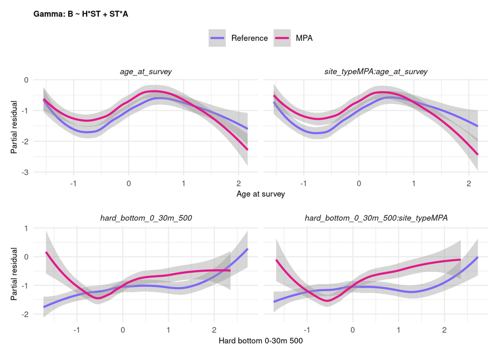

**Gamma GLMM: B ~ H * ST * A**

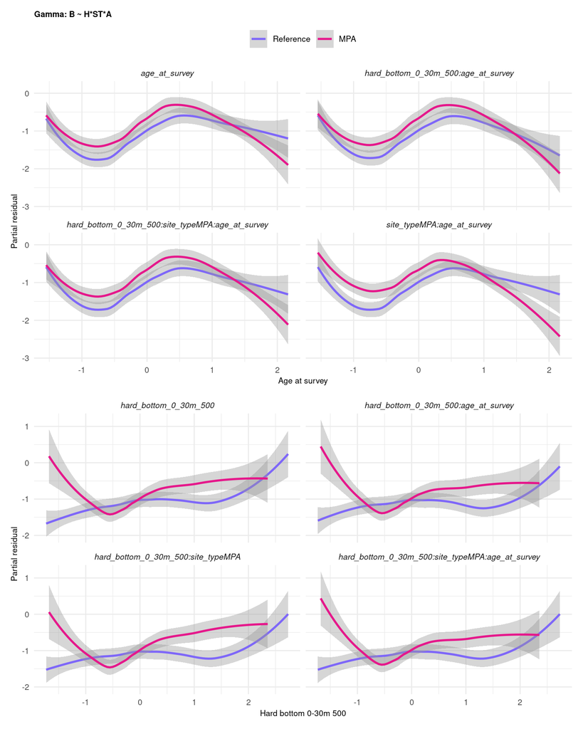

# GAM

## GAM: Smooth Age Only

```r
gam1 <- gam(kg_per_m2 ~ hard_bottom_0_30m_500 * site_type + s(age_at_survey, by = site_type) +
            s(year, bs = "re") + s(bioregion, bs = "re") + s(affiliated_mpa, bs = "re"),
          data = data_sp, method = "ML")

attr(gam1, "name") <- "GAM: B ~ H*ST + S(A, by = ST)"
```

## GAM: Smooth Age and Habitat

```r
gam2 <- gam(kg_per_m2 ~ s(hard_bottom_0_30m_500, by = site_type) + s(age_at_survey, by = site_type) + site_type +
            s(year, bs = "re") + s(bioregion, bs = "re") + s(affiliated_mpa, bs = "re"),
            data = data_sp, method = "ML")

attr(gam2, "name") <- "GAM: B ~ S(H, by = ST) + S(A, by = ST) + ST"
```

## GAM: Interactive Smooth

```r
gam3 <- gam(kg_per_m2 ~ ti(hard_bottom_0_30m_500, age_at_survey, by = site_type) + site_type +
            s(year, bs = "re") + s(bioregion, bs = "re") + s(affiliated_mpa, bs = "re"),
          data = data_sp, method = "ML")

attr(gam3, "name") <- "GAM: B ~ ti(H, A, by = ST)"
```

Summary:

```r
summary(gam1)
```

```
Family: gaussian
Link function: identity

Formula:
kg_per_m2 ~ hard_bottom_0_30m_500 * site_type + s(age_at_survey,
    by = site_type) + s(year, bs = "re") + s(bioregion, bs = "re") +
    s(affiliated_mpa, bs = "re")

Parametric coefficients:
                                    Estimate Std. Error t value Pr(>|t|)
(Intercept)                        1.850e-02  8.153e-03   2.268  0.02343 *
hard_bottom_0_30m_500              7.741e-05  7.169e-04   0.108  0.91403
site_typeMPA                       2.781e-03  9.770e-04   2.847  0.00447 **
hard_bottom_0_30m_500:site_typeMPA 5.925e-03  1.129e-03   5.249 1.72e-07 ***
---
Signif. codes:  0 '***' 0.001 '**' 0.01 '*' 0.05 '.' 0.1 ' ' 1

Approximate significance of smooth terms:
                                       edf Ref.df        F  p-value
s(age_at_survey):site_typeReference  3.175  3.919    4.104 0.003566 **
s(age_at_survey):site_typeMPA        5.424  6.492    7.612  < 2e-16 ***
s(year)                             11.996 20.000    2.245 4.55e-06 ***
s(bioregion)                         1.754  2.000 3049.175 7.55e-07 ***
s(affiliated_mpa)                   17.694 22.000   19.028 0.000767 ***
---
Signif. codes:  0 '***' 0.001 '**' 0.01 '*' 0.05 '.' 0.1 ' ' 1

R-sq.(adj) =  0.392   Deviance explained = 40.7%
-ML = -4353.6  Scale est. = 0.00037823  n = 1748
```

```r
summary(gam2)
```

```
Family: gaussian
Link function: identity

Formula:
kg_per_m2 ~ s(hard_bottom_0_30m_500, by = site_type) + s(age_at_survey,
    by = site_type) + site_type + s(year, bs = "re") + s(bioregion,
    bs = "re") + s(affiliated_mpa, bs = "re")

Parametric coefficients:
             Estimate Std. Error t value Pr(>|t|)
(Intercept)  0.017840   0.008109   2.200 0.027938 *
site_typeMPA 0.003365   0.001002   3.359 0.000798 ***
---
Signif. codes:  0 '***' 0.001 '**' 0.01 '*' 0.05 '.' 0.1 ' ' 1

Approximate significance of smooth terms:
                                               edf Ref.df        F  p-value
s(hard_bottom_0_30m_500):site_typeReference  4.388  5.388    3.984  0.00109 **
s(hard_bottom_0_30m_500):site_typeMPA        1.862  2.338   13.293 8.53e-07 ***
s(age_at_survey):site_typeReference          3.188  3.935    4.113  0.00337 **
s(age_at_survey):site_typeMPA                5.462  6.532    7.742  < 2e-16 ***
s(year)                                     12.103 20.000    2.173 2.57e-06 ***
s(bioregion)                                 1.740  2.000 1831.466 5.64e-07 ***
s(affiliated_mpa)                           17.763 22.000   16.903 1.38e-05 ***
---
Signif. codes:  0 '***' 0.001 '**' 0.01 '*' 0.05 '.' 0.1 ' ' 1

R-sq.(adj) =  0.402   Deviance explained = 41.8%
-ML = -4359.2  Scale est. = 0.00037202  n = 1748
```

```r
summary(gam3)
```

```
Family: gaussian
Link function: identity

Formula:
kg_per_m2 ~ ti(hard_bottom_0_30m_500, age_at_survey, by = site_type) +
    site_type + s(year, bs = "re") + s(bioregion, bs = "re") +
    s(affiliated_mpa, bs = "re")

Parametric coefficients:
              Estimate Std. Error t value Pr(>|t|)
(Intercept)  0.0191179  0.0082877   2.307  0.02119 *
site_typeMPA 0.0025480  0.0009818   2.595  0.00953 **
---
Signif. codes:  0 '***' 0.001 '**' 0.01 '*' 0.05 '.' 0.1 ' ' 1

Approximate significance of smooth terms:
                                                              edf Ref.df
ti(hard_bottom_0_30m_500,age_at_survey):site_typeReference  6.779  9.068
ti(hard_bottom_0_30m_500,age_at_survey):site_typeMPA        6.139  7.560
s(year)                                                    13.800 20.000
s(bioregion)                                                1.773  2.000
s(affiliated_mpa)                                          17.688 22.000
                                                                  F  p-value
ti(hard_bottom_0_30m_500,age_at_survey):site_typeReference    1.800  0.06673
ti(hard_bottom_0_30m_500,age_at_survey):site_typeMPA         13.202  < 2e-16
s(year)                                                       4.012 6.57e-06
s(bioregion)                                               6719.411 7.63e-07
s(affiliated_mpa)                                            19.949  0.00673

ti(hard_bottom_0_30m_500,age_at_survey):site_typeReference .
ti(hard_bottom_0_30m_500,age_at_survey):site_typeMPA       ***
s(year)                                                    ***
s(bioregion)                                               ***
s(affiliated_mpa)                                          **
---
Signif. codes:  0 '***' 0.001 '**' 0.01 '*' 0.05 '.' 0.1 ' ' 1

R-sq.(adj) =    0.4   Deviance explained = 41.6%
-ML = -4361.9  Scale est. = 0.00037287  n = 1748
```

Compare performance

```r
model_fit <- bind_rows(model_performance(gam1, estimator = "ML") %>% mutate(Model = attr(gam1, "name")),
                       model_performance(gam2, estimator = "ML") %>% mutate(Model = attr(gam2, "name")),
                       model_performance(gam3, estimator = "ML") %>% mutate(Model = attr(gam3, "name"))) %>%
  mutate(deltaAIC = AIC - min(AIC, na.rm = T)) %>%
  dplyr::select(Model, everything()) %>%
  arrange(AIC)
print(model_fit)
```

```
# Indices of model performance

Model                                       |       AIC |      AICc |       BIC |    R2 |  RMSE | Sigma | deltaAIC
------------------------------------------------------------------------------------------------------------------
GAM: B ~ S(H, by = ST) + S(A, by = ST) + ST | -8780.408 | -8776.674 | -8475.969 | 0.402 | 0.019 | 0.019 |    0.000
GAM: B ~ ti(H, A, by = ST)                  | -8779.520 | -8776.015 | -8484.516 | 0.400 | 0.019 | 0.019 |    0.888
GAM: B ~ H*ST + S(A, by = ST)               | -8761.031 | -8758.191 | -8495.329 | 0.392 | 0.019 | 0.019 |   19.377
```

# Compare All

```r
compare_all <- compare_performance(glm1, glm2, glm3, glm4, gglm1, gglm2, gam1, gam2, gam3) %>%
  arrange(AIC)
```

```
When comparing models, please note that probably not all models were fit
  from same data.
```

```r
print(compare_all)
```

```
# Comparison of Model Performance Indices

Name  |    Model |    AIC (weights) |   AICc (weights) |    BIC (weights) |  RMSE | Sigma |    R2 | R2 (cond.) | R2 (marg.) |   ICC
-----------------------------------------------------------------------------------------------------------------------------------
gglm2 | glmerMod | -23532.6 (>.999) | -23532.5 (>.999) | -23467.0 (>.999) | 0.097 | 2.358 |       |      0.987 |      0.001 | 0.987
gglm1 | glmerMod | -23479.3 (<.001) | -23479.2 (<.001) | -23424.7 (<.001) | 0.107 | 2.405 |       |      0.987 |  4.397e-04 | 0.987
glm4  |  lmerMod |  -8925.9 (<.001) |  -8925.7 (<.001) |  -8860.3 (<.001) | 0.018 | 0.018 |       |      0.436 |      0.029 | 0.419
glm2  |  lmerMod |  -8915.3 (<.001) |  -8915.2 (<.001) |  -8860.7 (<.001) | 0.018 | 0.018 |       |      0.428 |      0.024 | 0.414
gam2  |      gam |  -8780.4 (<.001) |  -8776.7 (<.001) |  -8476.0 (<.001) | 0.019 | 0.019 | 0.402 |            |            |
gam3  |      gam |  -8779.5 (<.001) |  -8776.0 (<.001) |  -8484.5 (<.001) | 0.019 | 0.019 | 0.400 |            |            |
gam1  |      gam |  -8761.0 (<.001) |  -8758.2 (<.001) |  -8495.3 (<.001) | 0.019 | 0.019 | 0.392 |            |            |
glm3  |  lmerMod |  -8662.2 (<.001) |  -8662.0 (<.001) |  -8596.6 (<.001) | 0.020 | 0.020 |       |      0.423 |      0.029 | 0.405
glm1  |  lmerMod |  -8652.0 (<.001) |  -8651.9 (<.001) |  -8597.4 (<.001) | 0.020 | 0.020 |       |      0.415 |      0.024 | 0.401
```

Check the model:

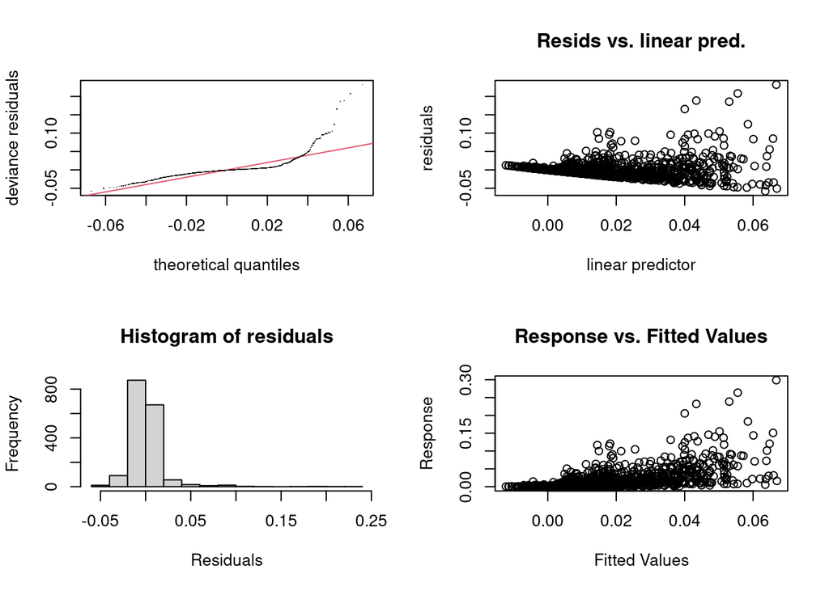

```
Method: ML   Optimizer: outer newton
full convergence after 7 iterations.
Gradient range [-0.001689483,3.893786e-05]
(score -4353.629 & scale 0.0003782312).
Hessian positive definite, eigenvalue range [0.3544521,874.1471].
Model rank =  69 / 69

Basis dimension (k) checking results. Low p-value (k-index<1) may
indicate that k is too low, especially if edf is close to k'.

                                       k'   edf k-index p-value
s(age_at_survey):site_typeReference  9.00  3.17    0.91  <2e-16 ***
s(age_at_survey):site_typeMPA        9.00  5.42    0.91  <2e-16 ***
s(year)                             21.00 12.00      NA      NA
s(bioregion)                         3.00  1.75      NA      NA
s(affiliated_mpa)                   23.00 17.69      NA      NA
---
Signif. codes:  0 '***' 0.001 '**' 0.01 '*' 0.05 '.' 0.1 ' ' 1
```

```r
par(mfrow = c(2, 2))

gam.check(gam1)
```

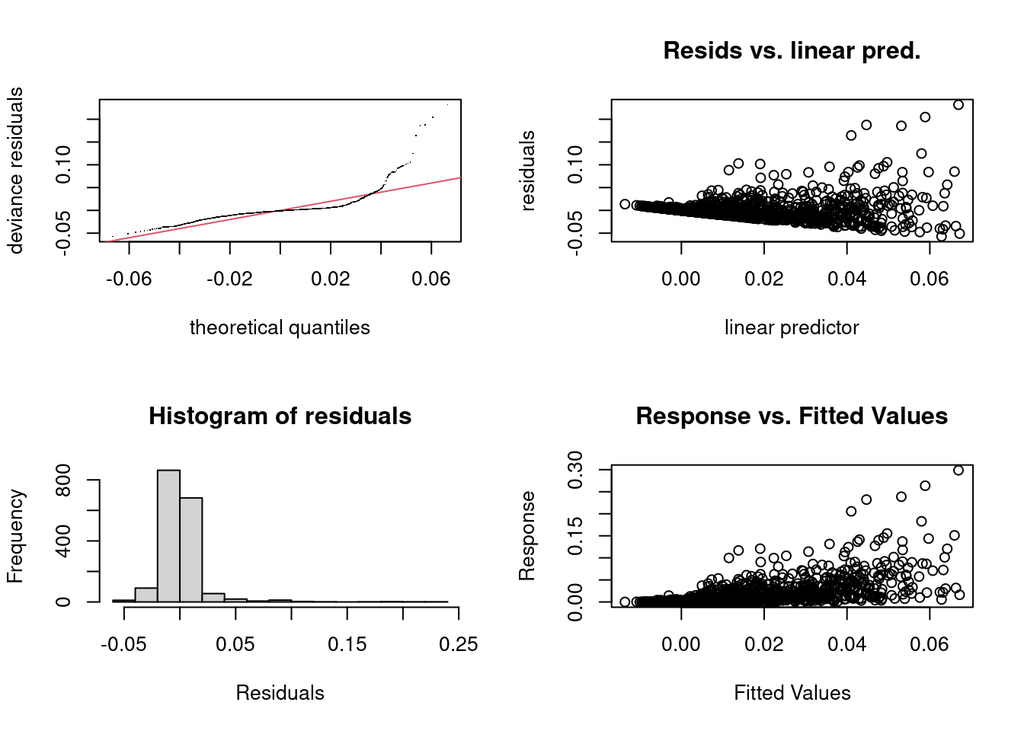

```
Method: ML   Optimizer: outer newton
full convergence after 9 iterations.
Gradient range [-0.002634815,0.001996334]
(score -4359.162 & scale 0.0003720154).
Hessian positive definite, eigenvalue range [0.321193,874.1544].
Model rank =  85 / 85

Basis dimension (k) checking results. Low p-value (k-index<1) may
indicate that k is too low, especially if edf is close to k'.

                                               k'   edf k-index p-value
s(hard_bottom_0_30m_500):site_typeReference  9.00  4.39    0.86  <2e-16 ***
s(hard_bottom_0_30m_500):site_typeMPA        9.00  1.86    0.86  <2e-16 ***
s(age_at_survey):site_typeReference          9.00  3.19    0.90  <2e-16 ***
s(age_at_survey):site_typeMPA                9.00  5.46    0.90  <2e-16 ***
s(year)                                     21.00 12.10      NA      NA
s(bioregion)                                 3.00  1.74      NA      NA
s(affiliated_mpa)                           23.00 17.76      NA      NA
---
Signif. codes:  0 '***' 0.001 '**' 0.01 '*' 0.05 '.' 0.1 ' ' 1
```

```r
gam.check(gam2)
```

Check k:

```r
mgcv::k.check(gam1)
```

```
                                    k'       edf   k-index p-value
s(age_at_survey):site_typeReference  9  3.174560 0.9062273       0
s(age_at_survey):site_typeMPA        9  5.423930 0.9062273       0
s(year)                             21 11.995799        NA      NA
s(bioregion)                         3  1.753589        NA      NA
s(affiliated_mpa)                   23 17.694357        NA      NA
```

Plot it:

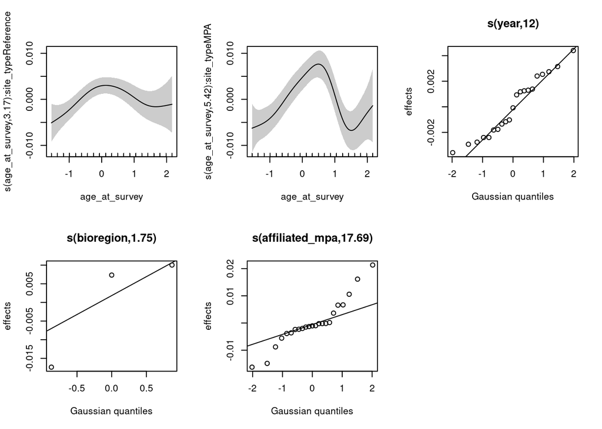

```r
plot(gam1, pages = 1, rug = TRUE, shade = TRUE)
```

## GAM: Smooth for MPA Age & Smooth for Hard Bottom

```r
gam2 <- gam(kg_per_m2 ~ s(hard_bottom_0_30m_500, by = site_type) + s(age_at_survey, by = site_type) +
            s(year, bs = "re") + s(bioregion, bs = "re") + s(affiliated_mpa, bs = "re"),
          data = data_kelp, # use unscaled data here
          method = "REML")

attr(gam2, "name") <- "GAM: B ~ S(H, by = ST) + S(A, by = ST)"
```

Summary:

```r
summary(gam2)
```

```
Family: gaussian
Link function: identity

Formula:
kg_per_m2 ~ s(hard_bottom_0_30m_500, by = site_type) + s(age_at_survey,
    by = site_type) + s(year, bs = "re") + s(bioregion, bs = "re") +
    s(affiliated_mpa, bs = "re")

Parametric coefficients:
            Estimate Std. Error t value Pr(>|t|)
(Intercept) 0.019897   0.009883   2.013   0.0442 *
---
Signif. codes:  0 '***' 0.001 '**' 0.01 '*' 0.05 '.' 0.1 ' ' 1

Approximate significance of smooth terms:
                                               edf Ref.df        F  p-value
s(hard_bottom_0_30m_500):site_typeReference  4.655  5.700    3.692  0.00165 **
s(hard_bottom_0_30m_500):site_typeMPA        1.895  2.379   11.921 2.45e-06 ***
s(age_at_survey):site_typeReference          3.891  4.764    3.796  0.00288 **
s(age_at_survey):site_typeMPA                5.698  6.773    7.663  < 2e-16 ***
s(year)                                     12.248 20.000    2.284 1.37e-06 ***
s(bioregion)                                 1.821  2.000 2169.339 8.02e-07 ***
s(affiliated_mpa)                           17.717 22.000   17.410 7.83e-07 ***
---
Signif. codes:  0 '***' 0.001 '**' 0.01 '*' 0.05 '.' 0.1 ' ' 1

R-sq.(adj) =  0.399   Deviance explained = 41.5%
-REML = -4331.8  Scale est. = 0.00037366  n = 1748
```

Check the model:

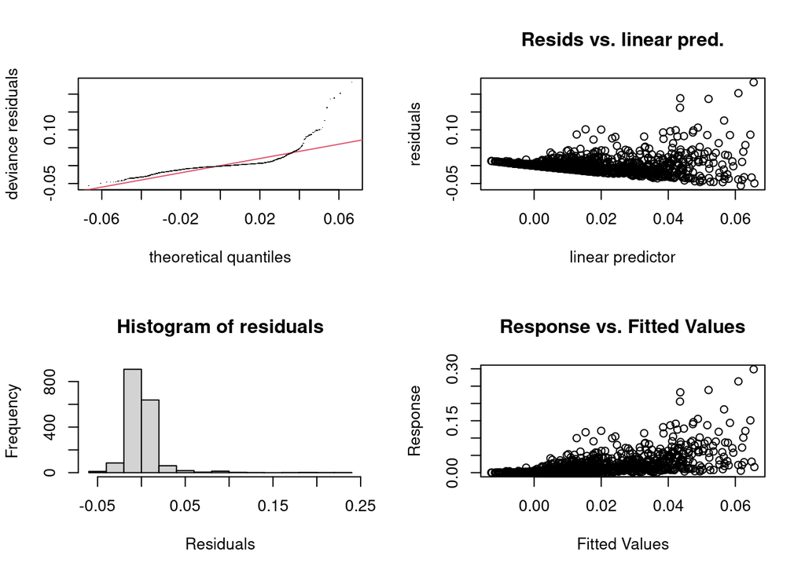

```
Method: REML   Optimizer: outer newton
full convergence after 8 iterations.
Gradient range [-0.0003026196,0.0001690585]
(score -4331.81 & scale 0.0003736587).
Hessian positive definite, eigenvalue range [0.1846813,871.6477].
Model rank =  84 / 84

Basis dimension (k) checking results. Low p-value (k-index<1) may
indicate that k is too low, especially if edf is close to k'.

                                               k'   edf k-index p-value
s(hard_bottom_0_30m_500):site_typeReference  9.00  4.65    0.86  <2e-16 ***
s(hard_bottom_0_30m_500):site_typeMPA        9.00  1.90    0.86  <2e-16 ***
s(age_at_survey):site_typeReference          9.00  3.89    0.90  <2e-16 ***
s(age_at_survey):site_typeMPA                9.00  5.70    0.90  <2e-16 ***
s(year)                                     21.00 12.25      NA      NA
s(bioregion)                                 3.00  1.82      NA      NA
s(affiliated_mpa)                           23.00 17.72      NA      NA
---
Signif. codes:  0 '***' 0.001 '**' 0.01 '*' 0.05 '.' 0.1 ' ' 1
```

```r
par(mfrow = c(2, 2))
gam.check(gam2)
```

Check k-index:

```r
mgcv::k.check(gam2)
```

```
                                            k'       edf   k-index p-value
s(hard_bottom_0_30m_500):site_typeReference  9  4.654676 0.8611613       0
s(hard_bottom_0_30m_500):site_typeMPA        9  1.895151 0.8611613       0
s(age_at_survey):site_typeReference          9  3.890902 0.9038221       0
s(age_at_survey):site_typeMPA                9  5.697504 0.9038221       0
s(year)                                     21 12.248003        NA      NA
s(bioregion)                                 3  1.820973        NA      NA
s(affiliated_mpa)                           23 17.717391        NA      NA
```

Plot it:

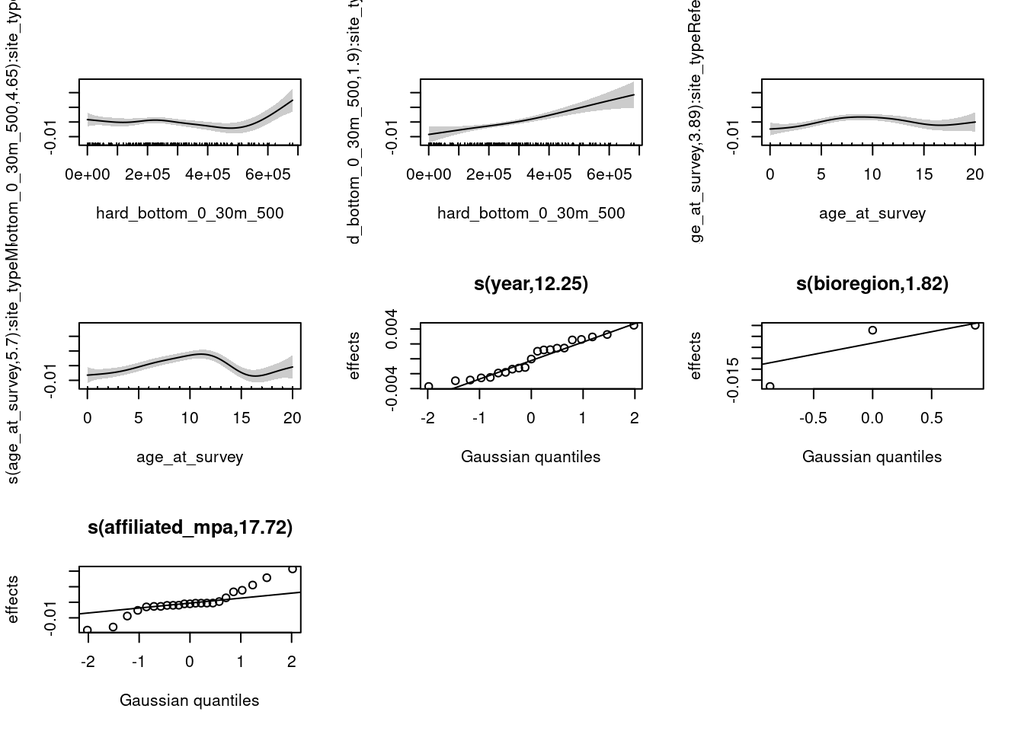

```r
plot(gam2, pages = 1, rug = TRUE, shade = TRUE)
```

## GAM: Interactive H * ST * A with Smooth

```r
gam3 <- gam(kg_per_m2 ~ ti(hard_bottom_0_30m_500, age_at_survey, by = site_type) +
            s(year, bs = "re") + s(bioregion, bs = "re") + s(affiliated_mpa, bs = "re"),
          data = data_kelp, # use unscaled data here
          method = "REML")

attr(gam3, "name") <- "GAM: B ~ ti(H, A, by = ST)"
```

Summary:

```r
summary(gam3)
```

```
Family: gaussian
Link function: identity

Formula:
kg_per_m2 ~ ti(hard_bottom_0_30m_500, age_at_survey, by = site_type) +
    s(year, bs = "re") + s(bioregion, bs = "re") + s(affiliated_mpa,
    bs = "re")

Parametric coefficients:
            Estimate Std. Error t value Pr(>|t|)
(Intercept)  0.02071    0.01013   2.044   0.0411 *
---
Signif. codes:  0 '***' 0.001 '**' 0.01 '*' 0.05 '.' 0.1 ' ' 1

Approximate significance of smooth terms:
                                                              edf Ref.df
ti(hard_bottom_0_30m_500,age_at_survey):site_typeReference  7.091  9.445
ti(hard_bottom_0_30m_500,age_at_survey):site_typeMPA        6.533  8.073
s(year)                                                    13.909 20.000
s(bioregion)                                                1.845  2.000
s(affiliated_mpa)                                          17.644 22.000
                                                                  F  p-value
ti(hard_bottom_0_30m_500,age_at_survey):site_typeReference    1.738   0.0812
ti(hard_bottom_0_30m_500,age_at_survey):site_typeMPA         12.714  < 2e-16
s(year)                                                       4.315 4.12e-06
s(bioregion)                                               7365.727  < 2e-16
s(affiliated_mpa)                                            23.084   0.0045

ti(hard_bottom_0_30m_500,age_at_survey):site_typeReference .
ti(hard_bottom_0_30m_500,age_at_survey):site_typeMPA       ***
s(year)                                                    ***
s(bioregion)                                               ***
s(affiliated_mpa)                                          **
---
Signif. codes:  0 '***' 0.001 '**' 0.01 '*' 0.05 '.' 0.1 ' ' 1

R-sq.(adj) =  0.399   Deviance explained = 41.5%
-REML = -4347.8  Scale est. = 0.00037376  n = 1748
```

Check the model:

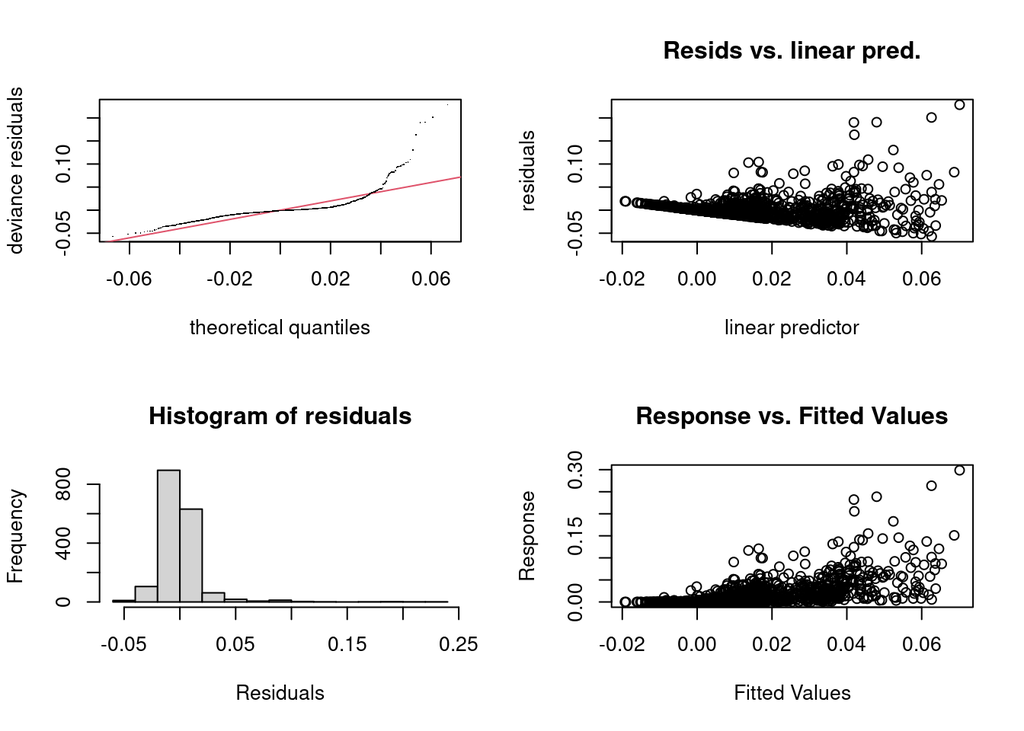

```
Method: REML   Optimizer: outer newton
full convergence after 8 iterations.
Gradient range [-8.432824e-05,6.587635e-05]
(score -4347.822 & scale 0.0003737596).
Hessian positive definite, eigenvalue range [0.412453,872.6565].
Model rank =  80 / 80

Basis dimension (k) checking results. Low p-value (k-index<1) may
indicate that k is too low, especially if edf is close to k'.

                                                              k'   edf k-index
ti(hard_bottom_0_30m_500,age_at_survey):site_typeReference 16.00  7.09    1.01
ti(hard_bottom_0_30m_500,age_at_survey):site_typeMPA       16.00  6.53    1.01
s(year)                                                    21.00 13.91      NA
s(bioregion)                                                3.00  1.85      NA
s(affiliated_mpa)                                          23.00 17.64      NA
                                                           p-value
ti(hard_bottom_0_30m_500,age_at_survey):site_typeReference    0.53
ti(hard_bottom_0_30m_500,age_at_survey):site_typeMPA          0.49
s(year)                                                         NA
s(bioregion)                                                    NA
s(affiliated_mpa)                                               NA
```

```r
par(mfrow = c(2, 2))
gam.check(gam3)
```

Check k:

```r
mgcv::k.check(gam3)
```

```
                                                           k'       edf
ti(hard_bottom_0_30m_500,age_at_survey):site_typeReference 16  7.091404
ti(hard_bottom_0_30m_500,age_at_survey):site_typeMPA       16  6.532865
s(year)                                                    21 13.909464
s(bioregion)                                                3  1.845379
s(affiliated_mpa)                                          23 17.643929
                                                            k-index p-value
ti(hard_bottom_0_30m_500,age_at_survey):site_typeReference 1.008139  0.6125
ti(hard_bottom_0_30m_500,age_at_survey):site_typeMPA       1.008139  0.5875
s(year)                                                          NA      NA
s(bioregion)                                                     NA      NA
s(affiliated_mpa)                                                NA      NA
```

Plot it:

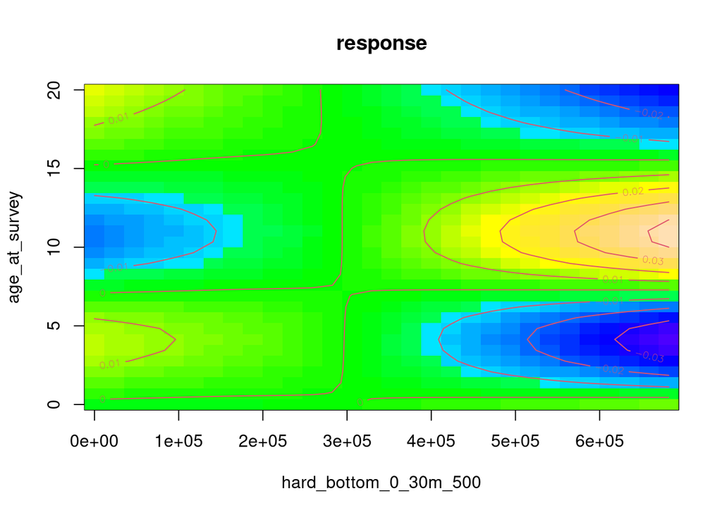

```r
vis.gam(gam3, view = c("hard_bottom_0_30m_500", "age_at_survey"),
        cond = list(site_type = "MPA"),
        type = "response", plot.type = "contour", color = "topo")
```

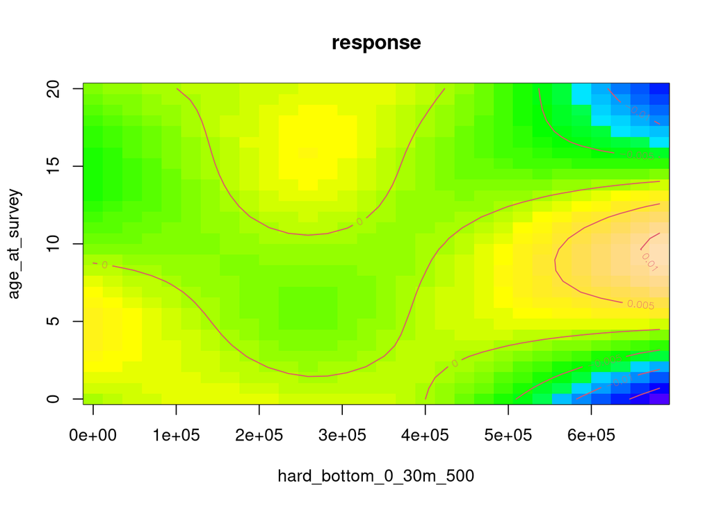

```r
vis.gam(gam3, view = c("hard_bottom_0_30m_500", "age_at_survey"),
        cond = list(site_type = "Reference"),
        type = "response", plot.type = "contour", color = "topo")
```

```r
# Diagnostics
#check_model(m1, residual_type = "simulated", check = c("ncv", "qq", "normality", "vif"))
#check_model(m2, residual_type = "simulated", check = c("ncv", "qq", "normality", "vif"))
#check_model(m3, residual_type = "simulated", check = c("ncv", "qq", "normality", "vif"))
```